# Bonytail (GIEL) Size-Tied Maturation Hazard — Growth-Track Sensitivity

Comparing Fabens-increment (F1, F2), age-based VBGF (A1), and the baseline scalar-lpsi joint robust-design fits

Author

Marsh & Associates

Published

September 15, 2026

## Background

This report compares three sensitivity fits of the joint two-stage robust-design model for bonytail (GIEL) at the three IPCA ponds (IP2, IP5, IP6), each using a different growth-model-derived **size-tied juvenile-to-adult maturation hazard** in place of the model’s original single scalar `lpsi[GIEL]` (a species-level, size-blind, time-constant monthly logit-hazard), against that original **baseline** fit. The three tracks differ only in which growth model supplied the hazard lookup table (`psi_lookup`, 8 TL bins x 24 months); everything else about the joint model and data build is identical across the four fits.

| Track | Growth-model source | Fit file |
| --- | --- | --- |
| F1 | Fabens increment, IPCA-only | `data/BWRobustDesign_MCMC_giel_F1.RData` |
| F2 | Fabens increment, IPCA + Cibola | `data/BWRobustDesign_MCMC_giel_F2.RData` |
| A1 | Age-based VBGF (shared-K, release-anchored), IPCA-only | `data/BWRobustDesign_MCMC_giel_A1.RData` |
| baseline | scalar `lpsi[GIEL]`, no hazard table | `data/BWRobustDesign_MCMC_giel.RData` |

All four fits use the same joint model structure (3 chains, 30k iterations / 10k burn-in / thin 10) and the same underlying `Fish`/contact data; see `AGENTS.md`’s “GIEL Size-Tied Maturation Hazard” section for the full design rationale and implementation notes, and `model/GIEL_MaturationHazard_Build.R` for how each track’s `psi_lookup` table was derived from its source growth model’s posterior.

## 1. The three hazard schedules

Each track converts posterior growth-model draws into a monthly maturation hazard for a juvenile bonytail as a function of its TL bin at tagging/capture and months elapsed since then. The panels below show, for each track, (a) the monthly hazard curve for three representative TL bins, and (b) the cumulative probability of having reached 250 mm TL after 6 months (one Apr–Sep growing season) as a function of starting TL bin — the version of this curve that is actually discretized into the joint model’s `psi_lookup`, not the smoother continuous-TL curves reported elsewhere for these growth models.

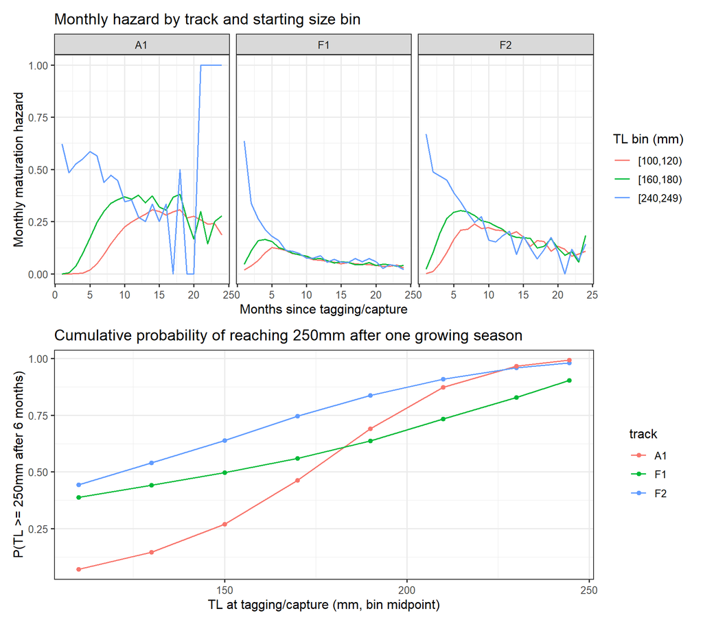

## 2. Known-alive constraint (`N_tag >= known alive`)

For every pond x month with at least one fish known alive (tagged, not yet removed, and either scanned in that window or known alive from a later contact), the posterior 2.5% quantile of tagged abundance (`sum(N_tag[pond, t, 1:2])`, juvenile + adult) must be at or above the directly-counted known-alive total.

Known-alive constraint: pond-months checked vs. violations

| Track | Pond-months checked | Violations |
| --- | --- | --- |
| F1 | 183 | 0 |
| F2 | 183 | 0 |
| A1 | 183 | 0 |

All three tracks pass with zero violations.

## 3. Convergence

Excluding the chronically-poor-mixing nuisance families (`N_tag`, `Tal`, `U`, `U0`, `RecJ`, `r`, `Atot` — recruitment/pool quantities documented throughout `AGENTS.md` as mixing poorly in essentially every GIEL/XYTE fit in this project regardless of any other model change), the remaining core hyperparameters (survival, detection, maturation, offsets, hyper-priors) converge acceptably in all three tracks.

Convergence by parameter family

| Track | n core | Max Rhat (core) | Core n > 1.1 | n nuisance | Max Rhat (nuisance) | Nuisance n > 1.1 |
| --- | --- | --- | --- | --- | --- | --- |
| F1 | 58 | 1.046 | 0 | 616 | 1.294 | 64 |
| F2 | 58 | 1.027 | 0 | 616 | 1.289 | 41 |
| A1 | 58 | 1.053 | 0 | 616 | 1.291 | 32 |

Worst core-parameter Rhats are among `lphiA[·,·]` (season-adult-survival) and `dE[·]` cells, all at or below ~1.05 — consistent with, and no worse than, prior GIEL fits in this project. The elevated nuisance-family Rhats are the same floating-point/mixing artifact documented throughout `AGENTS.md` for `N_tag`/`Tal` (pinned by the known-alive constraint, so within-chain SD is near zero and Rhat is not meaningful) and for recruitment nuisance parameters, not problems introduced by the hazard mechanism.

## 4. `lpsi_adj[GIEL]` plausibility

`lpsi_adj[1]` is the logit-scale correction the model applies on top of each track’s raw growth-model-derived hazard lookup table. A value near 0 means the robust-design contact/stage data agree with that track’s schedule as-is; a positive value means the data want **faster** maturation than the schedule predicts, a negative value **slower**.

lpsi_adj[GIEL] posterior by track

| Track | Mean | 2.5% | 97.5% |
| --- | --- | --- | --- |
| F1 | 0.227 | 0.044 | 0.402 |
| F2 | -0.645 | -0.852 | -0.430 |
| A1 | -0.643 | -1.081 | -0.118 |

All three are credibly nonzero (no CI includes 0), and the *direction* differs by track: F1’s positive offset means the contact data want maturation faster than the Fabens-IPCA-only schedule predicts — consistent with F1 giving the *slowest* raw schedule of the three (Section 1). F2 and A1’s negative offsets, of similar magnitude to each other, mean their faster raw schedules need to be slowed down to match the data. This is a genuine difference between tracks that mirrors the underlying divergence between the Fabens-increment and age-based VBGF growth-model curves, not measurement noise.

## 5. Core hyperparameter comparison

Core hyperparameters: mean (95% CI), F1 / F2 / A1 / baseline

| param | F1 | F2 | A1 | baseline |
| --- | --- | --- | --- | --- |
| mu_phi[1] | 2.714 (2.402, 3.045) | 2.720 (2.404, 3.052) | 2.730 (2.415, 3.048) | 2.711 (2.384, 3.030) |
| sigma_phi[1] | 0.848 (0.641, 1.134) | 0.848 (0.645, 1.128) | 0.847 (0.636, 1.135) | 0.849 (0.640, 1.134) |
| dJ[1] | 0.413 (0.233, 0.592) | 0.361 (0.196, 0.524) | 0.313 (0.151, 0.472) | 0.453 (0.284, 0.634) |
| dE[1] | -1.726 (-3.020, -0.550) | -1.780 (-3.433, -0.504) | -1.741 (-3.154, -0.566) | -1.739 (-3.154, -0.547) |
| dE[2] | -1.415 (-2.033, -0.858) | -1.464 (-2.141, -0.890) | -1.535 (-2.151, -0.962) | -1.446 (-2.069, -0.874) |
| dE[3] | -2.369 (-6.692, -0.092) | -2.361 (-6.699, -0.101) | -2.386 (-6.568, -0.091) | -2.423 (-6.762, -0.095) |
| lpsi[1] | -2.233 (-2.906, -1.378) | -2.158 (-2.848, -1.061) | -2.027 (-2.759, -0.952) | -1.697 (-1.854, -1.538) |
| lpsi_adj[1] | 0.227 (0.044, 0.402) | -0.645 (-0.852, -0.430) | -0.643 (-1.081, -0.118) | NA |
| lp[1, 1] | -2.030 (-2.137, -1.921) | -1.753 (-1.860, -1.650) | -1.462 (-1.545, -1.380) | -2.197 (-2.311, -2.088) |
| lp[2, 1] | 0.158 (-0.073, 0.365) | -0.038 (-0.359, 0.209) | -0.369 (-0.581, -0.141) | 0.009 (-0.231, 0.229) |
| lp[3, 1] | 0.203 (0.078, 0.328) | 0.184 (0.059, 0.307) | 0.065 (-0.097, 0.208) | 0.193 (0.065, 0.319) |
| lp[1, 2] | -0.836 (-0.891, -0.783) | -0.842 (-0.896, -0.788) | -0.883 (-0.939, -0.828) | -0.835 (-0.887, -0.783) |
| lp[2, 2] | -0.549 (-0.597, -0.501) | -0.533 (-0.583, -0.486) | -0.512 (-0.558, -0.464) | -0.546 (-0.593, -0.499) |
| lp[3, 2] | -0.676 (-0.729, -0.627) | -0.663 (-0.716, -0.611) | -0.640 (-0.692, -0.591) | -0.671 (-0.722, -0.621) |
| g_eff[1] | 0.916 (0.882, 0.951) | 0.909 (0.875, 0.943) | 0.902 (0.869, 0.937) | 0.912 (0.877, 0.948) |

## 6. FY2022 (IP2) / FY2020 (IP5) event-adjusted realized annual survival

Both confirmed die-off events (IP2, Jan–Jul 2022, 7 of 12 FY2022 months flagged; IP5, Jan–Sep 2020, 9 of 12 FY2020 months flagged; see `data/BWDieOffEvents.csv` and `AGENTS.md`) are handled by a per-pond fixed survival-reducing offset `dE[pond]` applied only in the flagged months, on top of that pond-season’s baseline `lphiA`. Realized annual survival over the event season is therefore `plogis(lphiA)^(12 - nEvt) * plogis(lphiA + dE)^nEvt`.

Event-adjusted realized annual survival by track

| Track | Pond | FY | Event-adjusted (mean, 95% CI) | No-event-adjustment comparison |
| --- | --- | --- | --- | --- |
| F1 | IP2 | 2022 | 0.090 (0.045, 0.147) | 0.474 |
| F1 | IP5 | 2020 | 0.046 (0.020, 0.085) | 0.353 |
| F2 | IP2 | 2022 | 0.093 (0.044, 0.156) | 0.489 |
| F2 | IP5 | 2020 | 0.044 (0.019, 0.080) | 0.363 |
| A1 | IP2 | 2022 | 0.097 (0.048, 0.157) | 0.488 |
| A1 | IP5 | 2020 | 0.043 (0.019, 0.081) | 0.383 |

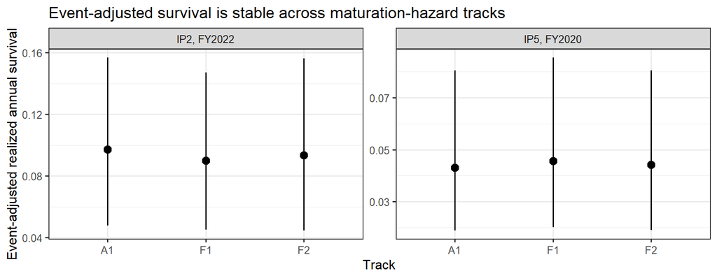

All three tracks give essentially the same event-adjusted realized survival for both die-off seasons — confirming that the maturation-hazard track choice does not materially affect the die-off (`dE`) estimates or their downstream realized-survival implications, consistent with Section 5’s finding that the tracks differ mainly in maturation-timing quantities, not survival.

## 7. Conclusion

All three growth-track sensitivity fits (F1, F2, A1) pass the known-alive constraint with zero violations and converge acceptably (core-parameter Rhat at or below ~1.05 in every fit). Survival and die-off estimates are robust to the choice of maturation-hazard track — the size-tied maturation submodel is largely separable from the rest of the joint model, mirroring the pattern already seen for XYTE’s density-dependent size-split submodel.

The substantive difference between tracks is the sign and magnitude of `lpsi_adj[GIEL]`: F1 (the slowest raw schedule) is corrected faster by the data, while F2 and A1 (faster raw schedules) are corrected slower by a similar amount. This reflects the same underlying divergence between the Fabens-increment and age-based VBGF growth-model curves already flagged as an open reconciliation item in `AGENTS.md` and the design plan file. No track is disqualified by this comparison; choosing among them, reconciling the two growth models directly, or reporting all three as a sensitivity range on maturation timing remains a modeling decision for BK. Because survival estimates are unaffected by this choice, that decision can be made independently of any of the survival/die-off conclusions already reported elsewhere for this model.